# Top Eight Leading Causes of Death in the U.S.

## Diving Deeper: Age-Adjusted Death Rates

Although total death statistics are insightful, they do not take into account changes in population. Between 1999 and 2016, the U.S. population [increased](https://www.worldometers.info/world-population/us-population/) from roughly 280 million to 322 million.

Age-adjusted death rates give us a better understanding of trends among the leading causes of death. This proportional statistic represents number of deaths per 100,000 people, and can be calculated specific to cause of death, state, and year.

For example, the age-adjusted death rates of the two leading causes of death, heart disease and cancer, tell a different story from the total annual number of deaths. Although total deaths are increasing, the death rates are generally falling - which bodes well for treatment.

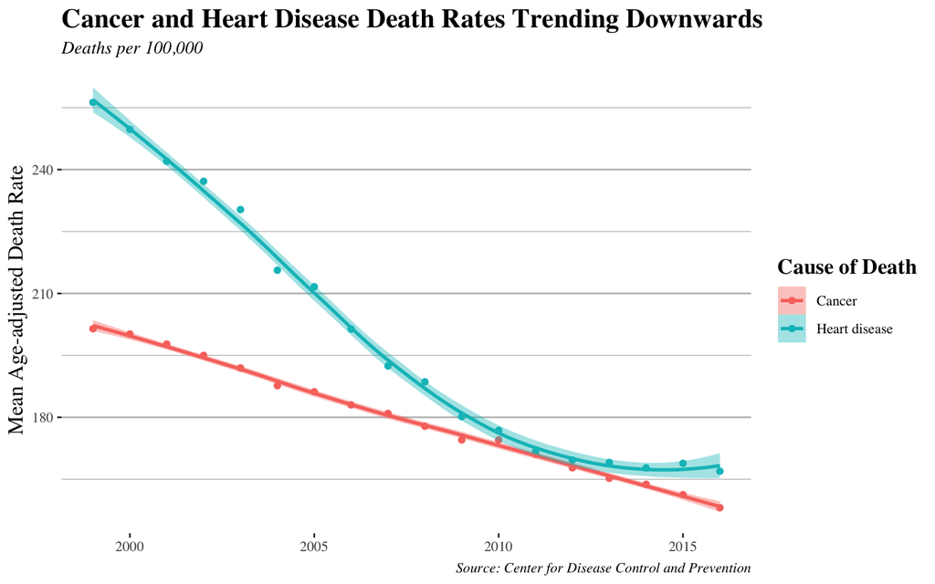

The death rates of the other leading causes of deaths are more of a mixed-bag.

Notable gains are clear in the prevention of strokes and deaths related to influenza and pneumonia.

Unfortunately, Alzheimer’s disease and deaths related to unintentional injuries are on the rise. Alzheimer’s is [projected to cost](https://www.alz.org/news/2018/new_alzheimer_s_association_report_reveals_sharp_i) $1.1 trillion by 2050. Meanwhile, the rise in deaths related to unintentional injuries is likely related to the opioid epidemic, which began its [third wave](https://www.cdc.gov/drugoverdose/epidemic/index.html) in 2013.

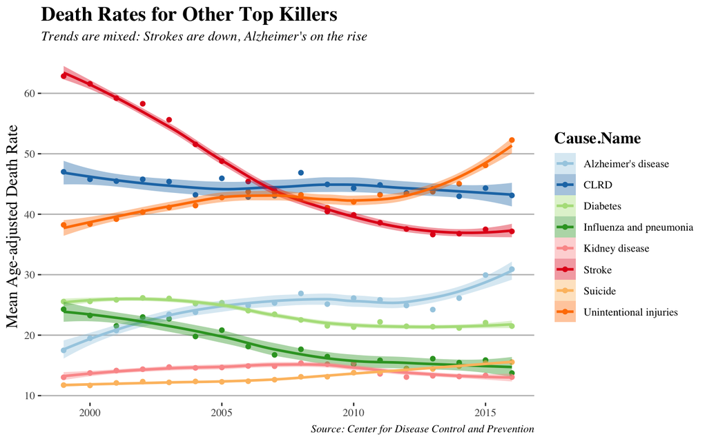

## Looking at the States

The leading causes of deaths can be isolated according to each specific State. For example, heart disease is the leading cause of death nationwide - but are some state populations more at risk?

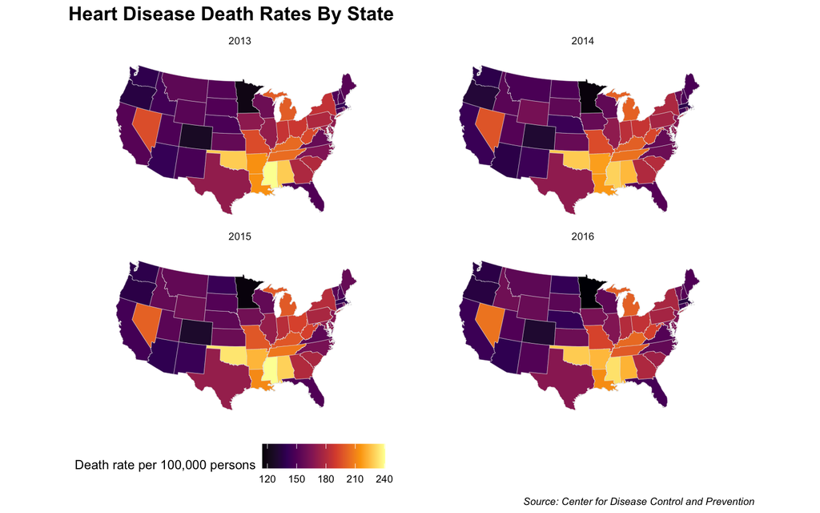

The regional South is particularly at-risk for deaths from heart disease, where death rates are almost 235 per 100,000.

Suicide, another leading cause of death, disproportionately affects a different U.S. region - in this case, the West, particularly the Rocky Mountain region.

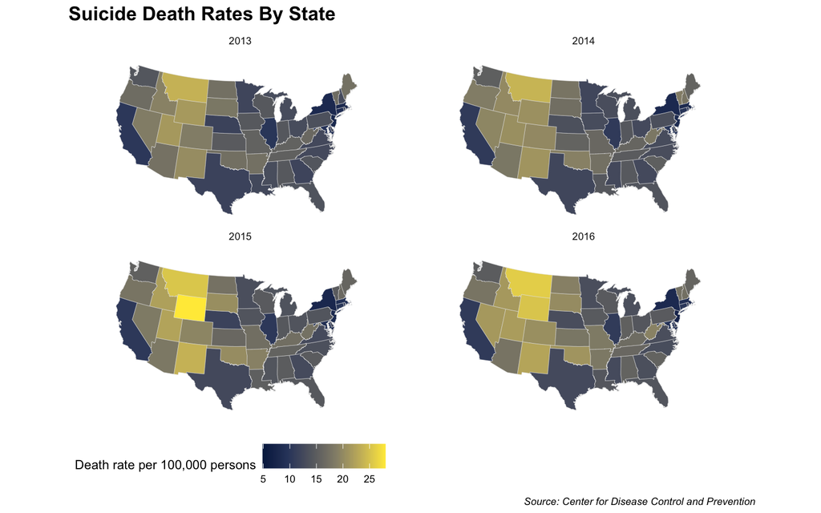

One particularly interesting cause of death is “unintentional injuries”, which could include anything from vehicular accidents to selfie-stick mishaps. You’ll see that the rate of death increased sharply in West Virginia, and to a lesser degree in New England.

The likely culprit? Drug overdoes related to the opioid epidemic, which has hit these areas [particularly hard](https://www.drugabuse.gov/opioid-summaries-by-state/west-virginia-opioid-summary).

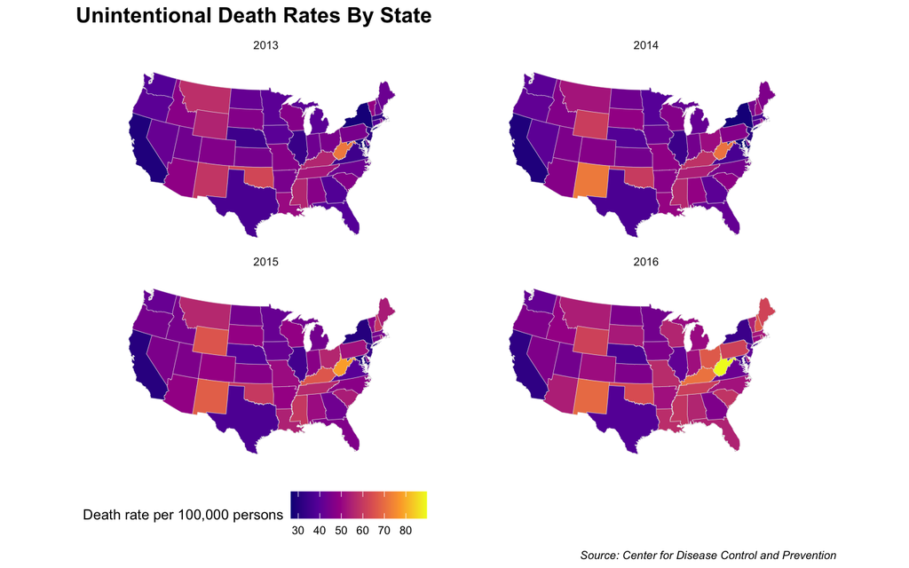

Although the CDC’s current dataset ends in 2016, this analysis provides an instructive foundation for understanding the leading causes of death in the United States. This analysis would be much improved if the CDC collected this data alongside other variables such as gender, race, and age.

I will be interested to see how trends develop as more data is released!